# Ventas Apple

Andrea Jiménez Zúñiga

## Introducción:

El objetivo principal es predecir las ventas de Apple. Para ello es necesario elegir el modelo ETS y ARIMA que mejor predice las ventas.

```r
library(forecast)
require(forecast)
library(xts) # PARA MANEJAR DATOS DE SERIES TEMPORALES (DATOS DE TIEMPO CONTINUO)
```

```r
require(xts)
library(ggplot2)
require(ggplot2)
```

## Carga de datos

```r
rawData <- read.csv2("./IngresosApple.csv")
rawVentas<-rawData$Ingresos
rawDate<-seq(as.Date("2008/04/01"), as.Date("2017/07/01"), by = "quarter") # Lo paso a trimestres y formato fecha
```

Creo un objeto xts para pasa los trimestres que están de tipo caracter a tipo fecha.

```r
xVentas=xts(rawVentas,order.by=rawDate)
```

Paso los datos de xVentas a trimestres, para que me salga en el mismo formato que mi base de datos rawData.

```r
xVentas=to.quarterly(xVentas)
```

Paso los datos a formato zoo.

```r
zVentas=as.zoo(xVentas$xVentas.Close)

names(zVentas)="Ventas"
```

## Representación Gráfica

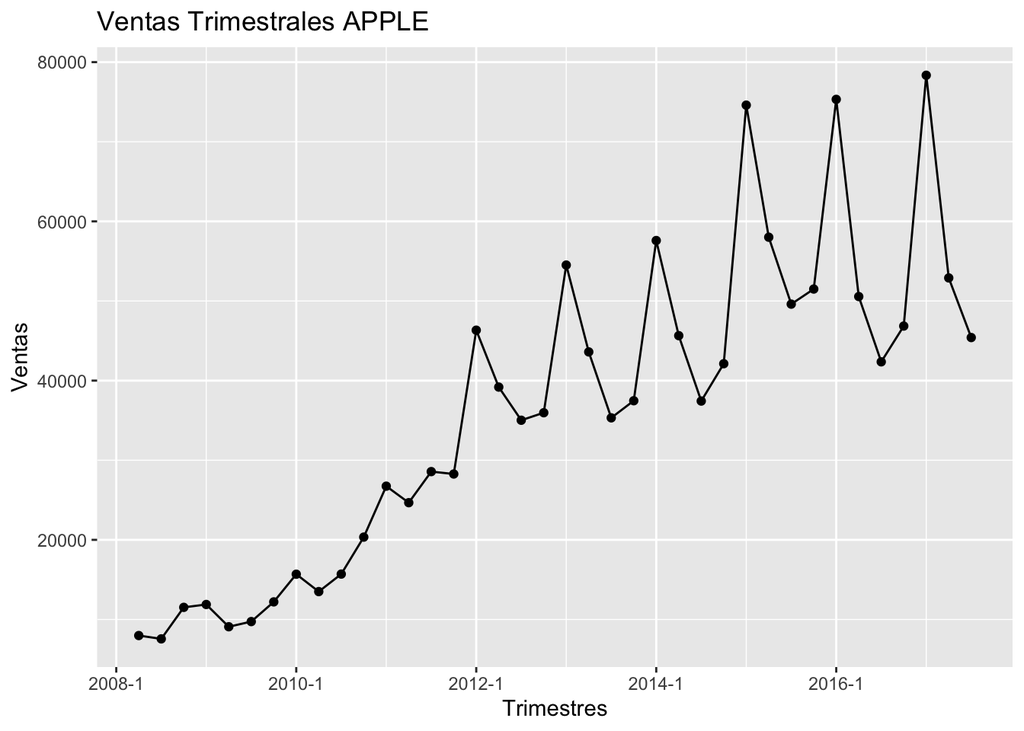

```r
df_new <- data.frame(value = as.vector(zVentas),
                     time = time(zVentas))
ggplot(df_new)+geom_point(aes(x=time,y=value))+geom_line(aes(x=time,y=value))+ylab("Ventas")+ggtitle("Ventas Trimestrales APPLE")+xlab("Trimestres")
```

Se puede observar que las series no son estacionarias al igual que su media y varianza.

Ahora voy a excluir 3 periodos, ya que para hacer los modelos tengo que dejar fuera de la estimación los trimestres de 2017. Para poder hacer mi modelo voya hacer un periodo de training y de test. Primero tengo que indicar que voy a eliminar los 3 últimos datos (los de 2017).

```r
cOmit=3
nObs=length(zVentas) #Numero de observaciones
```

A continuación se realiza el Training

```r
oVentas <- window(zVentas,start=index(zVentas[1]),end=index(zVentas[nObs-cOmit])) #TRAINING
```

Realizo el Testing

```r
pVentas <- window(zVentas,start=index(zVentas[nObs-cOmit+1]),end=index(zVentas[nObs])) #TESTING
```

## ARIMA Model:

Como se trata de un modelo cuya serie es no estacionaria y su media y varianza varían ralizo el ARIMA para convertir la serie en estacionaria. Voy a utilizar el modelo automático para obtener el mejor modelo.

```r
fit2=auto.arima(oVentas,lambda=0)
summary(fit2)
```

```
## Series: oVentas
## ARIMA(0,1,0)(0,1,0)[4]
## Box Cox transformation: lambda= 0
##
## sigma^2 estimated as 0.01472:  log likelihood=20.72
## AIC=-39.45   AICc=-39.3   BIC=-38.04
##
## Training set error measures:
##                     ME     RMSE      MAE       MPE     MAPE      MASE      ACF1
## Training set -764.5058 4786.405 3054.054 -1.321616 8.284962 0.4406634 0.1269135
```

Análisis de residuos

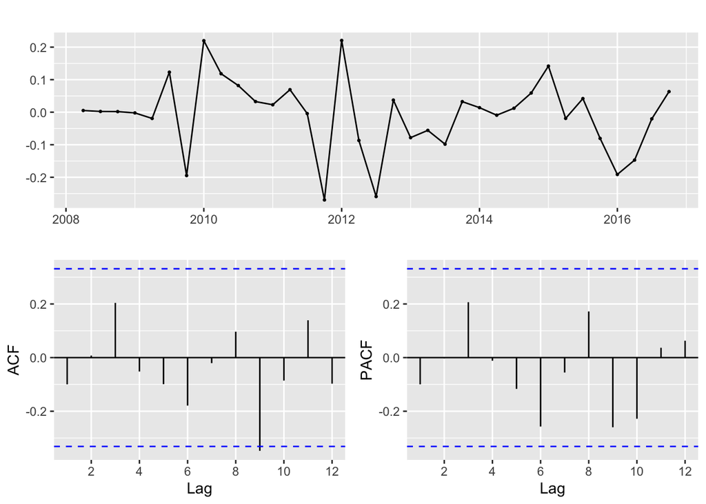

```r
ggtsdisplay(fit2$residuals)
```

## Box-Ljung Test

```r
Box.test(fit2$residuals,lag=4, fitdf=1, type="Lj")
```

```
##
##  Box-Ljung test
##
## data:  fit2$residuals
## X-squared = 2.1794, df = 3, p-value = 0.536
```

```r
Box.test(fit2$residuals,lag=8, fitdf=1, type="Lj")
```

```
##
##  Box-Ljung test
##
## data:  fit2$residuals
## X-squared = 4.501, df = 7, p-value = 0.7206
```

```r
Box.test(fit2$residuals,lag=6, fitdf=1, type="Lj")
```

```
##
##  Box-Ljung test
##
## data:  fit2$residuals
## X-squared = 4.0334, df = 5, p-value = 0.5446
```

Como todos los p-valores son mayores de 0.05, por lo que se acepta la hipótesis nula, por lo que no hay autocorrelación y muestra que hay ruido blanco, por lo que se confirma lo observado en la gráfica anterior.

## Predicción

Ahora predigo:

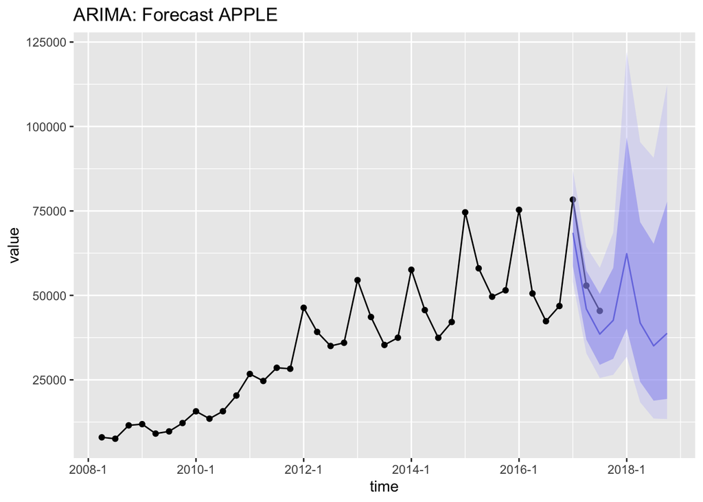

```r
#Forecast
fventas.arima=forecast(fit2)

#plot
ggplot(df_new)+geom_point(aes(x=time,y=value))+geom_line(aes(x=time,y=value))+ geom_forecast(fventas.arima,alpha=0.4)+ggtitle("ARIMA: Forecast APPLE")
```

```r
#data
fventas.arima
```

```
##         Point Forecast    Lo 80    Hi 80    Lo 95     Hi 95
## 2017 Q1       68524.50 58656.57 80052.53 54021.77  86920.63
## 2017 Q2       45993.21 36914.17 57305.26 32857.77  64379.78
## 2017 Q3       38534.34 29436.35 50444.28 25525.07  58174.00
## 2017 Q4       42622.67 31230.74 58169.99 26490.28  68579.55
## 2018 Q1       62338.78 40156.60 96774.23 31816.09 122143.34
## 2018 Q2       41841.40 24416.21 71702.49 18358.80  95360.44
## 2018 Q3       35055.84 18821.04 65294.59 13541.05  90754.54
## 2018 Q4       38775.11 19344.31 77723.59 13387.03 112310.89
```

La sombra azul muestra las predicciones y en la tabla se puede observar lo que se predice que va a ingresar en cada trimestre.

## ETS:

Otro modelo es el ETS.

```r
etsfit<-ets(oVentas,damped = TRUE)
#forecast model
fventas.ets=forecast(etsfit)
#Results
summary(fventas.ets)
```

```
##
## Forecast method: ETS(M,Ad,M)
##
## Model Information:
## ETS(M,Ad,M)
##
## Call:
##  ets(y = oVentas, damped = TRUE)
##
##   Smoothing parameters:
##     alpha = 0.4866
##     beta  = 0.4866
##     gamma = 0.5134
##     phi   = 0.8412
##
##   Initial states:
##     l = 7124.7146
##     b = 1557.5091
##     s = 1.246 1.0241 0.8186 0.9113
##
##   sigma:  0.1279
##
##      AIC     AICc      BIC
## 706.7948 715.9615 722.3483
##
## Error measures:
##                    ME     RMSE      MAE      MPE    MAPE     MASE      ACF1
## Training set 336.7763 4012.287 2865.906 1.165156 8.77168 0.413516 0.1371203
##
## Forecasts:
##         Point Forecast     Lo 80     Hi 80      Lo 95     Hi 95
## 2017 Q1       69929.62 58470.251  81388.98  52404.028  87455.21
## 2017 Q2       53001.85 40992.858  65010.84  34635.683  71368.01
## 2017 Q3       47699.77 32676.602  62722.94  24723.817  70675.72
## 2017 Q4       52146.25 30474.789  73817.70  19002.612  85289.88
## 2018 Q1       77165.52 32841.231 121489.81   9377.369 144953.67
## 2018 Q2       57654.24 18635.617  96672.86  -2019.595 117328.07
## 2018 Q3       51287.35 11072.981  91501.71 -10215.219 112789.91
## 2018 Q4       55539.00  5827.416 105250.58 -20488.305 131566.30
```

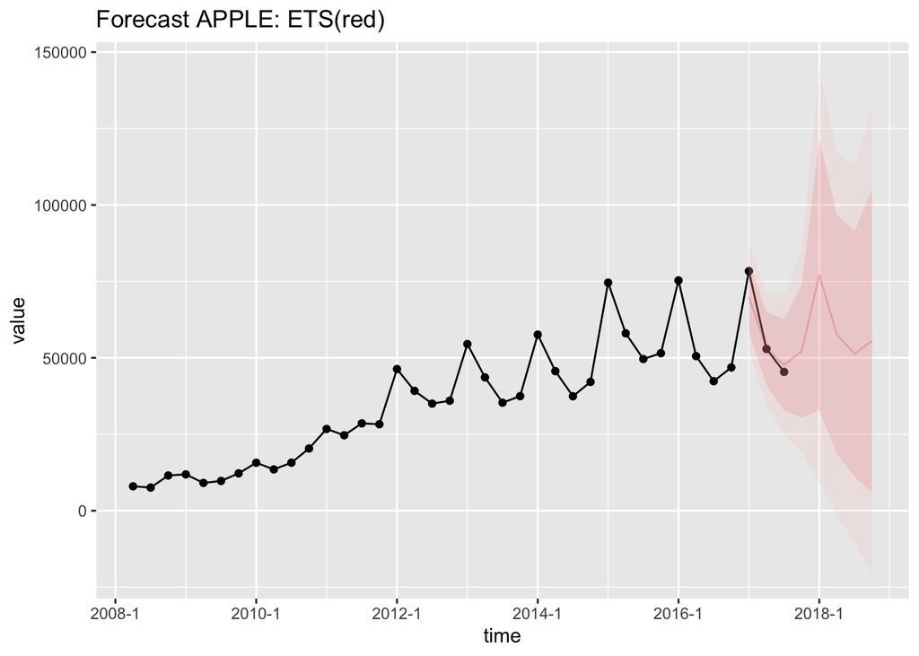

```r
#Plot
ggplot(df_new)+geom_point(aes(x=time,y=value))+
  geom_line(aes(x=time,y=value))+
  geom_forecast(fventas.ets,color="red", alpha=0.183,plot.conf = FALSE)+
  ggtitle("Forecast APPLE: ETS(red)")
```

Se puede observar en la sombra roja las predicciones, y en la tabla se puede ver las predicciones de ingresos para cada trimestre, dándonos valores más altos con el ETS.

## Selección del modelo:

```r
summary(fit2)
```

```
## Series: oVentas
## ARIMA(0,1,0)(0,1,0)[4]
## Box Cox transformation: lambda= 0
##
## sigma^2 estimated as 0.01472:  log likelihood=20.72
## AIC=-39.45   AICc=-39.3   BIC=-38.04
##
## Training set error measures:
##                     ME     RMSE      MAE       MPE     MAPE      MASE      ACF1
## Training set -764.5058 4786.405 3054.054 -1.321616 8.284962 0.4406634 0.1269135
```

```r
summary(fventas.ets)
```

```
##
## Forecast method: ETS(M,Ad,M)
##
## Model Information:
## ETS(M,Ad,M)
##
## Call:
##  ets(y = oVentas, damped = TRUE)
##
##   Smoothing parameters:
##     alpha = 0.4866
##     beta  = 0.4866
##     gamma = 0.5134
##     phi   = 0.8412
##
##   Initial states:
##     l = 7124.7146
##     b = 1557.5091
##     s = 1.246 1.0241 0.8186 0.9113
##
##   sigma:  0.1279
##
##      AIC     AICc      BIC
## 706.7948 715.9615 722.3483
##
## Error measures:
##                    ME     RMSE      MAE      MPE    MAPE     MASE      ACF1
## Training set 336.7763 4012.287 2865.906 1.165156 8.77168 0.413516 0.1371203
##
## Forecasts:
##         Point Forecast     Lo 80     Hi 80      Lo 95     Hi 95
## 2017 Q1       69929.62 58470.251  81388.98  52404.028  87455.21
## 2017 Q2       53001.85 40992.858  65010.84  34635.683  71368.01
## 2017 Q3       47699.77 32676.602  62722.94  24723.817  70675.72
## 2017 Q4       52146.25 30474.789  73817.70  19002.612  85289.88
## 2018 Q1       77165.52 32841.231 121489.81   9377.369 144953.67
## 2018 Q2       57654.24 18635.617  96672.86  -2019.595 117328.07
## 2018 Q3       51287.35 11072.981  91501.71 -10215.219 112789.91
## 2018 Q4       55539.00  5827.416 105250.58 -20488.305 131566.30
```

Para seleccionar el mejor modelo me voy a fijar en el AIC de cada uno, es decir, en el AIC de ARIMA y en el AIC de ETS. Para seleccionar el modelo me quedo con el que tenga mejor AIC, es decir, el que sea más bajo. En este caso, el AIC es el modelo ARIMA, ya que su AIC es el más bajo.